# DEFENSIVE TRAITS H.murinum SIBECOL 2025

Andrés Delgado Galán

2025-05-18

### H.murinum - PRODUCCIÓN DE FLORES

**flor ~ trat + clip + trat:clip**  
n = **19** (40 0s were removed)

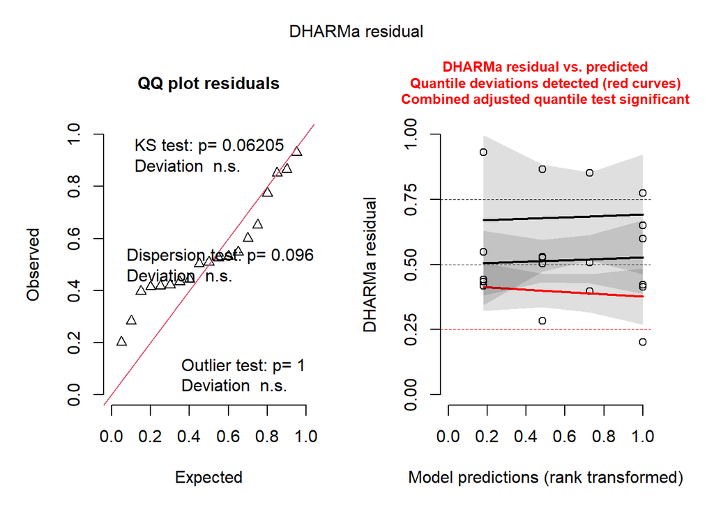

##### HOflor Post-hoc Comparisons with Tukeys HSD

| contrast | trat | estimate | SE | df | z.ratio | p.value |
| --- | --- | --- | --- | --- | --- | --- |
| no - yes | ex | 0.1743534 | 0.5855400 | Inf | 0.2977651 | 0.7658824 |
| no - yes | gra | -0.0408220 | 0.4743416 | Inf | -0.0860604 | 0.9314184 |

| contrast | clip | estimate | SE | df | z.ratio | p.value |
| --- | --- | --- | --- | --- | --- | --- |
| ex - gra | no | 0.0408220 | 0.5700877 | Inf | 0.0716065 | 0.9429151 |
| ex - gra | yes | -0.1743534 | 0.4928054 | Inf | -0.3537978 | 0.7234905 |

ANOVA Results for HOflor Model

| Response | Predictor | Chisq | Df | Pr(>Chisq) |
| --- | --- | --- | --- | --- |
| HO flor | trat | 0.049 | 1 | 0.825 |
| HO flor | clip | 0.015 | 1 | 0.904 |
| HO flor | trat:clip | 0.082 | 1 | 0.775 |

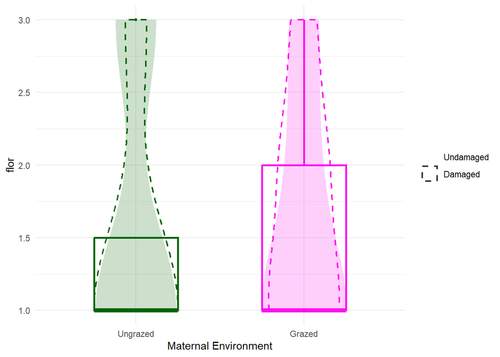

### H.murinum - PRODUCCIÓN DE FRUTOS

**fruto ~ trat + clip + trat:clip**  
n = **16** (43 0s removed)

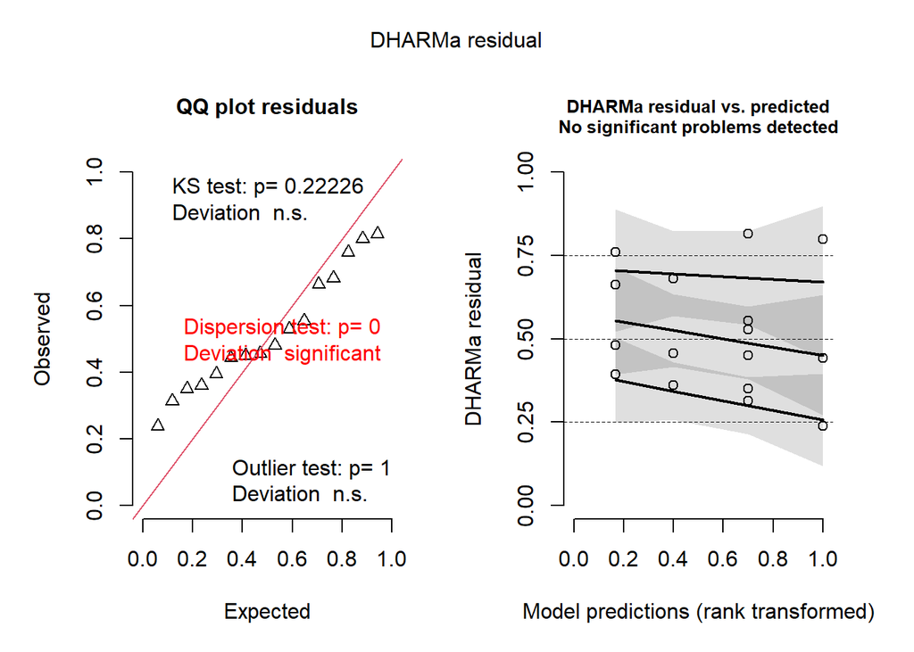

##### HOfruto Post-hoc Comparisons with Tukeys HSD

| contrast | trat | estimate | SE | df | z.ratio | p.value |
| --- | --- | --- | --- | --- | --- | --- |
| no - yes | ex | 0.5108261 | 0.7302967 | Inf | 0.6994775 | 0.4842537 |
| no - yes | gra | -0.1541512 | 0.6267832 | Inf | -0.2459402 | 0.8057285 |

| contrast | clip | estimate | SE | df | z.ratio | p.value |
| --- | --- | --- | --- | --- | --- | --- |
| ex - gra | no | 0.5108263 | 0.6708204 | Inf | 0.7614950 | 0.4463615 |
| ex - gra | yes | -0.1541509 | 0.6900655 | Inf | -0.2233859 | 0.8232352 |

ANOVA Results for HOfruto Model

| Response | Predictor | Chisq | Df | Pr(>Chisq) |
| --- | --- | --- | --- | --- |
| HO fruto | trat | 0.152 | 1 | 0.696 |
| HO fruto | clip | 0.072 | 1 | 0.788 |
| HO fruto | trat:clip | 0.477 | 1 | 0.490 |

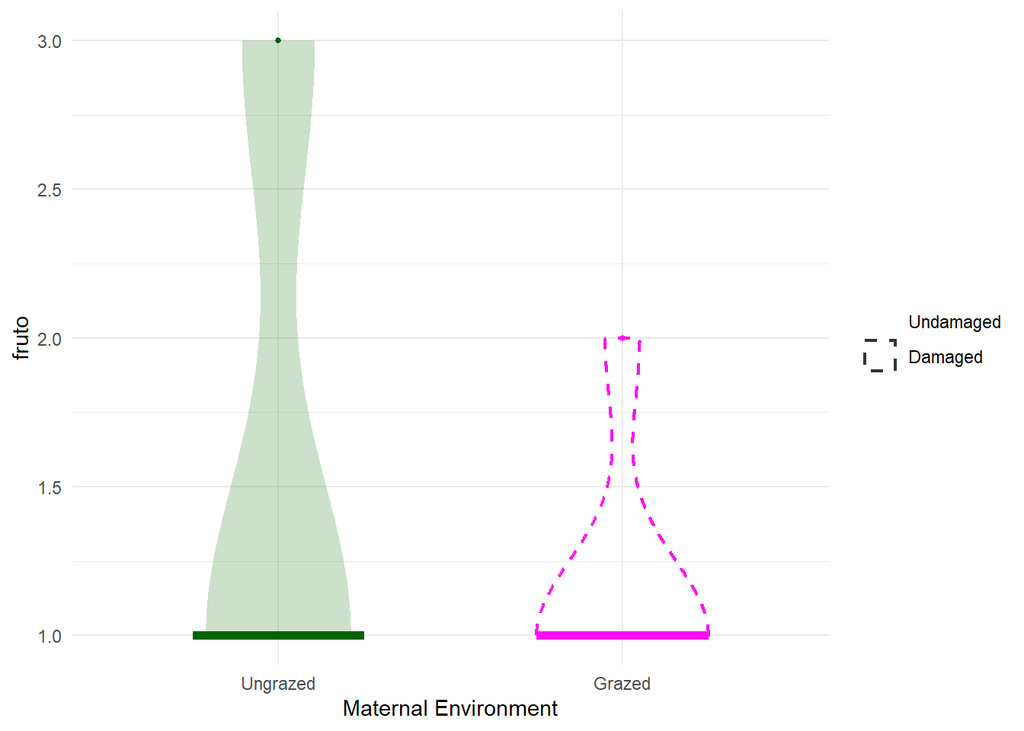

### H.murinum - PRODUCCIÓN DE HOJAS

**hojas ~ trat + clip + trat:clip**  
n = **57**

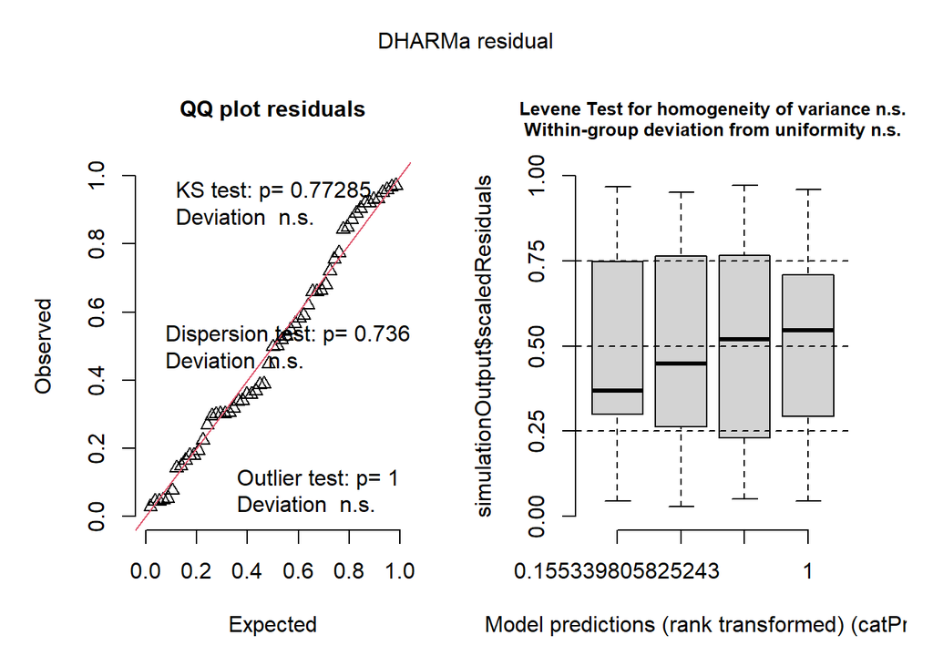

##### HOhojas Post-hoc Comparisons with Tukeys HSD

| contrast | trat | estimate | SE | df | z.ratio | p.value |
| --- | --- | --- | --- | --- | --- | --- |
| no - yes | ex | -0.0885282 | 0.1268285 | Inf | -0.6980151 | 0.4851678 |
| no - yes | gra | 0.1971128 | 0.1337751 | Inf | 1.4734645 | 0.1406258 |

| contrast | clip | estimate | SE | df | z.ratio | p.value |
| --- | --- | --- | --- | --- | --- | --- |
| ex - gra | no | -0.2722097 | 0.1339720 | Inf | -2.0318402 | 0.0421698 |
| ex - gra | yes | 0.0134313 | 0.1266205 | Inf | 0.1060754 | 0.9155225 |

ANOVA Results for HOhojas Model

| Response | Predictor | Chisq | Df | Pr(>Chisq) |
| --- | --- | --- | --- | --- |
| HO hojas | trat | 1.739 | 1 | 0.187 |
| HO hojas | clip | 0.257 | 1 | 0.612 |
| HO hojas | trat:clip | 2.401 | 1 | 0.121 |

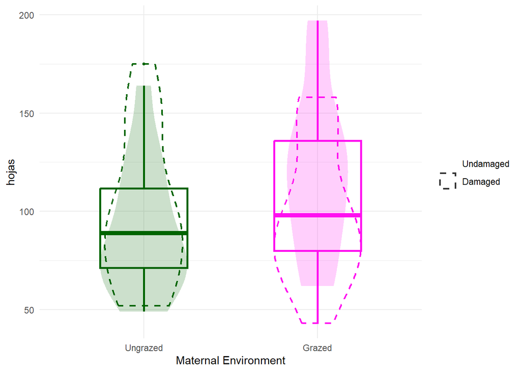

### H.murinum - ALTURA MÁXIMA

**altura ~ trat + clip + trat:clip**  
n = **27**

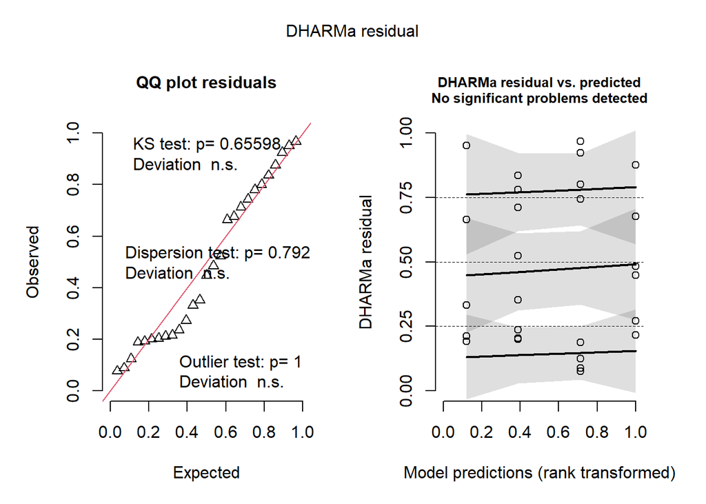

R² = **0.0407265**

##### HOaltura Post-hoc Comparisons with Tukeys HSD

| contrast | trat | estimate | SE | df | t.ratio | p.value |
| --- | --- | --- | --- | --- | --- | --- |
| no - yes | ex | 7.208333 | 5.160049 | 23 | 1.396951 | 0.1757623 |
| no - yes | gra | -7.975000 | 5.446934 | 23 | -1.464127 | 0.1566944 |

| contrast | clip | estimate | SE | df | t.ratio | p.value |
| --- | --- | --- | --- | --- | --- | --- |
| ex - gra | no | 8.683333 | 5.785570 | 23 | 1.500861 | 0.1469959 |
| ex - gra | yes | -6.500000 | 4.777277 | 23 | -1.360608 | 0.1868232 |

ANOVA Results for HOaltura Model

| Response | Predictor | Sum Sq | Df | F value | Pr(>F) |
| --- | --- | --- | --- | --- | --- |
| HO altura | trat | 0.799 | 1 | 0.009 | 0.926 |
| HO altura | clip | 0.005 | 1 | 0.000 | 0.994 |
| HO altura | trat:clip · | 373.838 | 1 | 4.095 | 0.055 |
| HO altura | Residuals | 2099.658 | 23 | NA | NA |

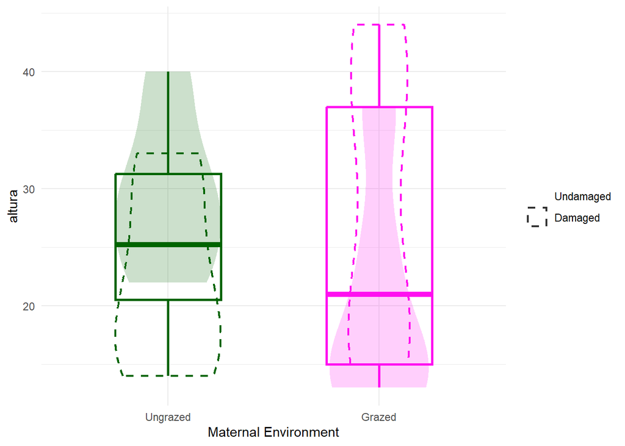

### H.murinum - SEMILLAS/FRUTO

**seedfruto ~ trat + clip + trat:clip**  
n = **9** (los resultados del ANOVA no tienen sentido porque algunos tratamientos solo tienen 1 o 2 réplicas)

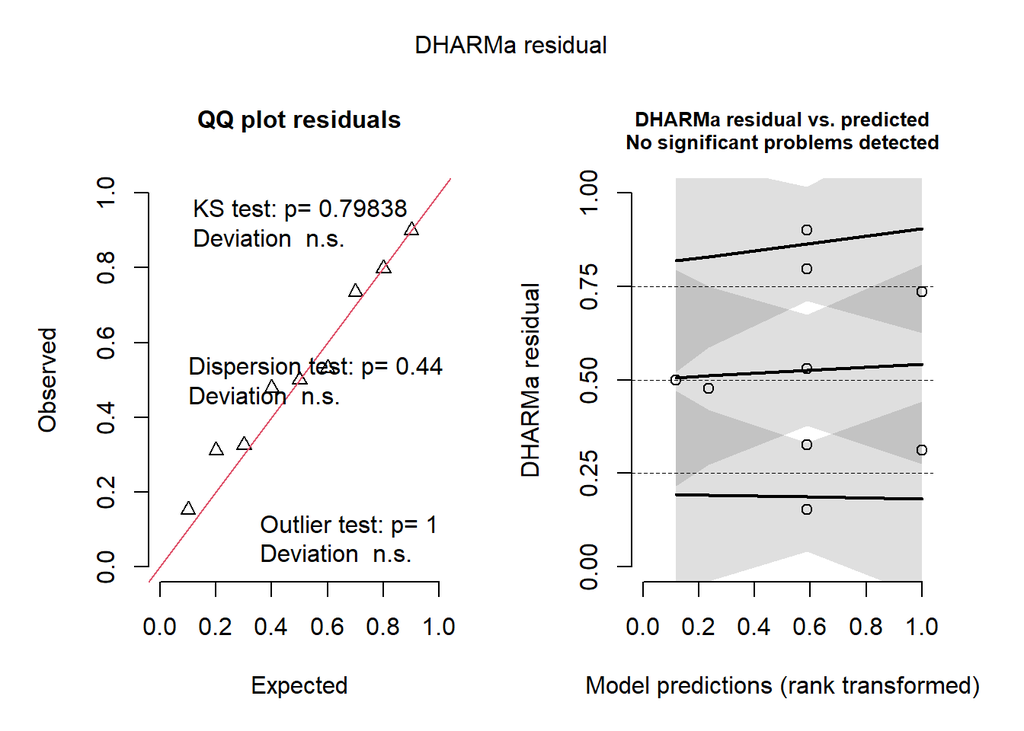

##### HOseedfruto Post-hoc Comparisons with Tukeys HSD

| contrast | trat | estimate | SE | df | z.ratio | p.value |
| --- | --- | --- | --- | --- | --- | --- |
| no - yes | ex | 0.268264 | 0.3260945 | Inf | 0.8226571 | 0.4107030 |
| no - yes | gra | -1.057790 | 0.4625094 | Inf | -2.2870678 | 0.0221919 |

| contrast | clip | estimate | SE | df | z.ratio | p.value |
| --- | --- | --- | --- | --- | --- | --- |
| ex - gra | no | 1.2237755 | 0.4790029 | Inf | 2.5548394 | 0.0106237 |
| ex - gra | yes | -0.1022788 | 0.3013523 | Inf | -0.3393996 | 0.7343087 |

ANOVA Results for HOseedfruto Model

| Response | Predictor | Chisq | Df | Pr(>Chisq) |
| --- | --- | --- | --- | --- |
| HO seedfruto | trat | 1.152 | 1 | 0.283 |
| HO seedfruto | clip | 0.417 | 1 | 0.519 |
| HO seedfruto | trat:clip * | 5.490 | 1 | 0.019 |

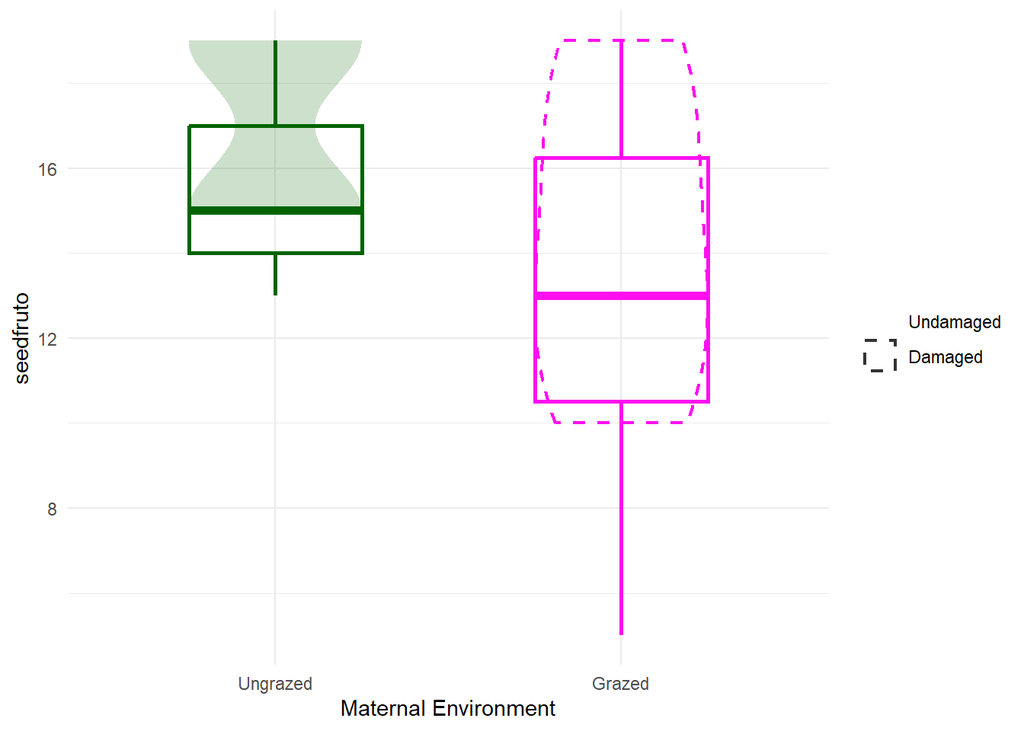

### H.murinum - PRODUCCIÓN DE SEMILLAS

**seedtotal ~ trat + clip + trat:clip**  
n = **10** (43 0s removed)

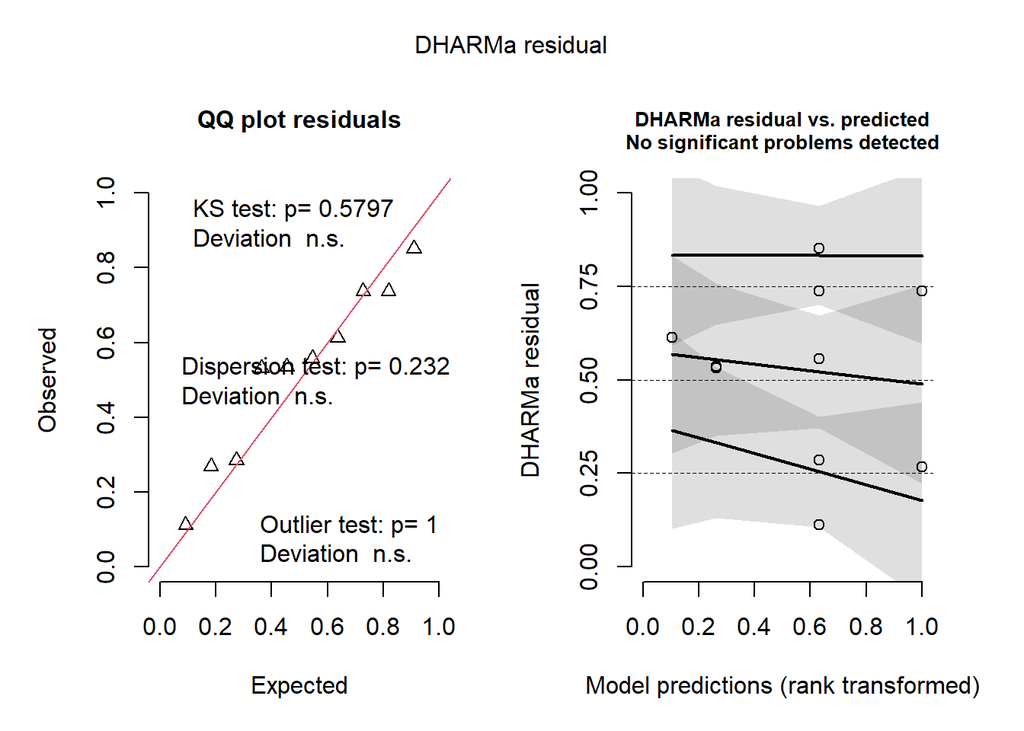

##### HOseedtotal Post-hoc Comparisons with Tukeys HSD

| contrast | trat | estimate | SE | df | z.ratio | p.value |
| --- | --- | --- | --- | --- | --- | --- |
| no - yes | ex | 0.2682639 | 0.2605250 | Inf | 1.029705 | 0.3031485 |
| no - yes | gra | -1.1878435 | 0.4606464 | Inf | -2.578645 | 0.0099189 |

| contrast | clip | estimate | SE | df | z.ratio | p.value |
| --- | --- | --- | --- | --- | --- | --- |
| ex - gra | no | 1.223775 | 0.4789695 | Inf | 2.555018 | 0.0106182 |
| ex - gra | yes | -0.232332 | 0.2250703 | Inf | -1.032264 | 0.3019485 |

ANOVA Results for HOseedtotal Model

| Response | Predictor | Chisq | Df | Pr(>Chisq) |
| --- | --- | --- | --- | --- |
| HO seedtotal | trat | 0.023 | 1 | 0.879 |
| HO seedtotal | clip | 0.139 | 1 | 0.709 |
| HO seedtotal | trat:clip ** | 7.570 | 1 | 0.006 |

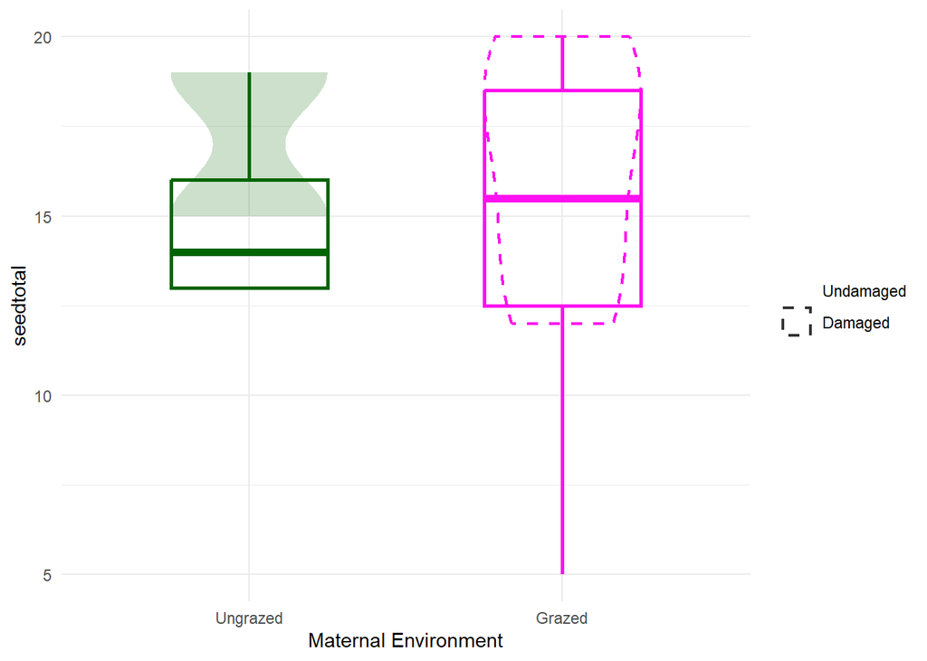

### H.murinum - PESO MEDIO DE LAS SEMILLAS

**massseed ~ trat + clip + trat:clip**  
n = **8**

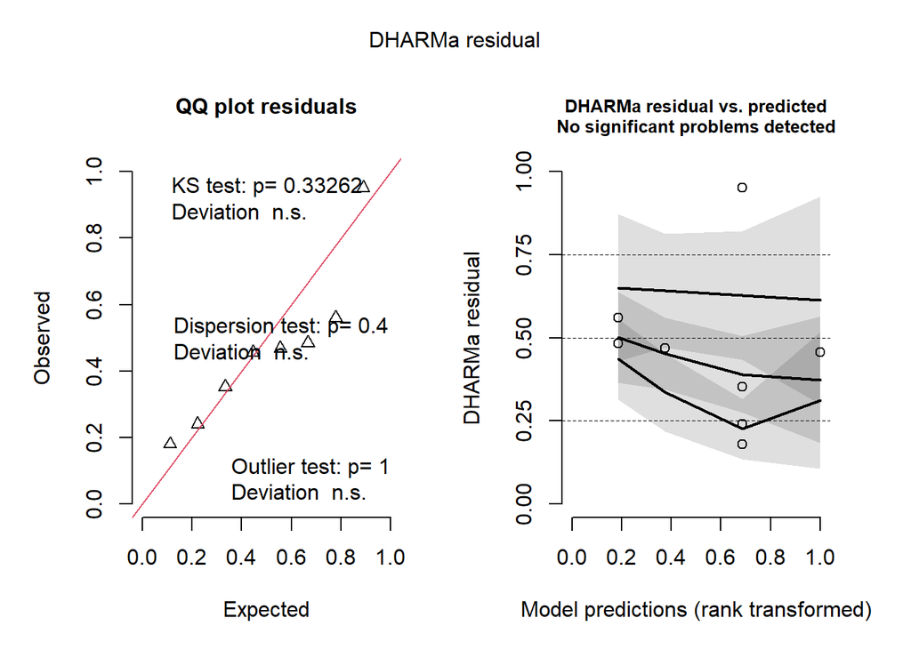

R² = **-0.2144623**

##### HOmassseed Post-hoc Comparisons with Tukeys HSD

| contrast | trat | estimate | SE | df | t.ratio | p.value |
| --- | --- | --- | --- | --- | --- | --- |
| no - yes | ex | -5.0e-05 | 0.0013573 | 4 | -0.0368386 | 0.9723789 |
| no - yes | gra | 7.5e-05 | 0.0012390 | 4 | 0.0605320 | 0.9546356 |

| contrast | clip | estimate | SE | df | t.ratio | p.value |
| --- | --- | --- | --- | --- | --- | --- |
| ex - gra | no | -0.001150 | 0.0013573 | 4 | -0.8472877 | 0.4445543 |
| ex - gra | yes | -0.001025 | 0.0012390 | 4 | -0.8272706 | 0.4545804 |

ANOVA Results for HOmassseed Model

| Response | Predictor | Sum Sq | Df | F value | Pr(>F) |
| --- | --- | --- | --- | --- | --- |
| HO massseed | trat | 0 | 1 | 1.398 | 0.303 |
| HO massseed | clip | 0 | 1 | 0.000 | 0.985 |
| HO massseed | trat:clip | 0 | 1 | 0.005 | 0.949 |
| HO massseed | Residuals | 0 | 4 | NA | NA |

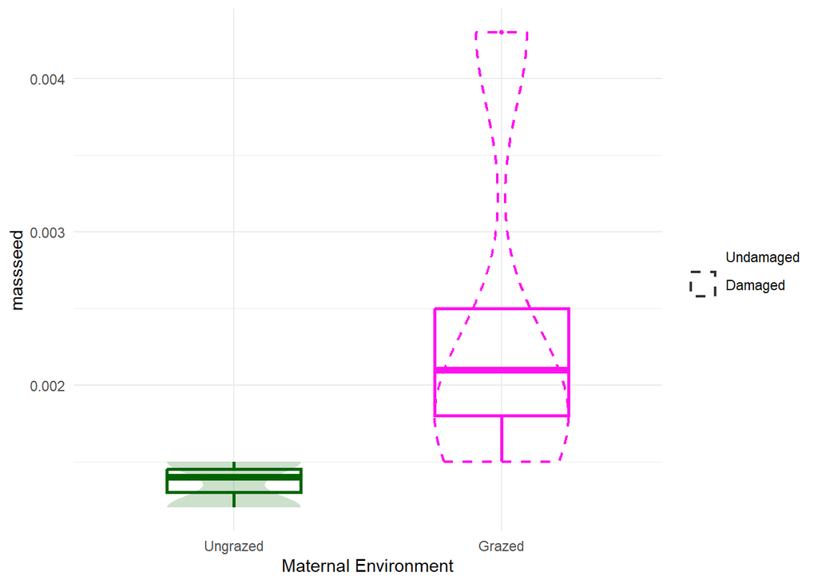

### H.murinum - SLA

**SLA ~ trat + clip + trat:clip**  
n = **50**

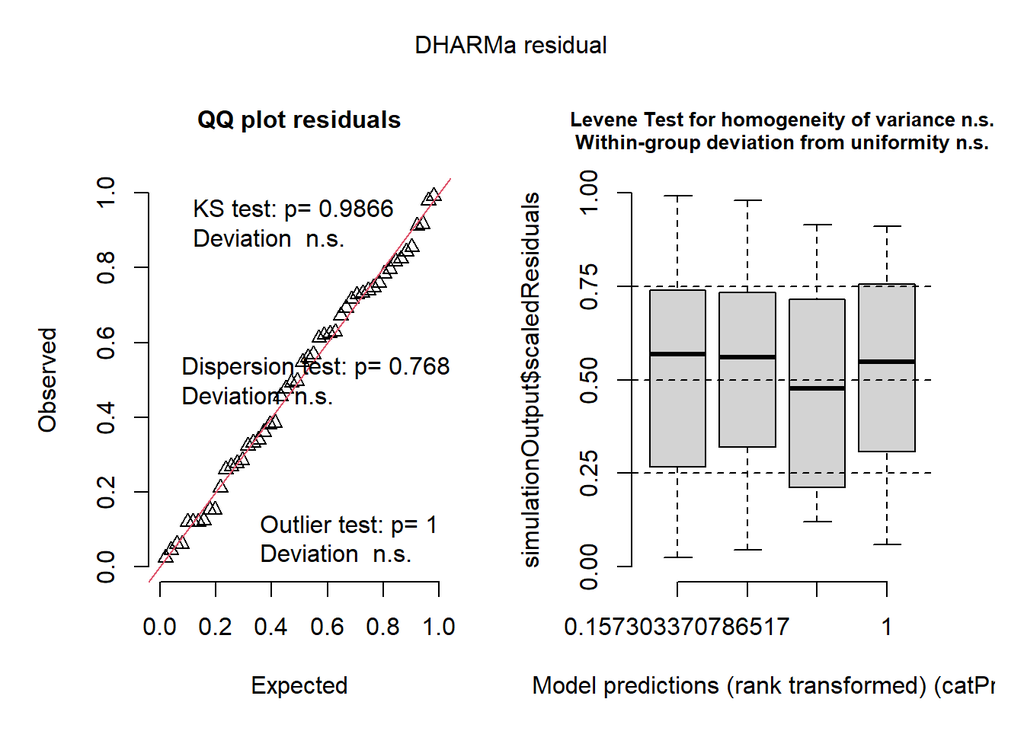

R² = **-0.0277492**

##### HOSLA Post-hoc Comparisons with Tukeys HSD

| contrast | trat | estimate | SE | df | t.ratio | p.value |
| --- | --- | --- | --- | --- | --- | --- |
| no - yes | ex | 7.025115 | 32.85085 | 46 | 0.2138488 | 0.8316100 |
| no - yes | gra | -31.899077 | 30.31208 | 46 | -1.0523551 | 0.2981335 |

| contrast | clip | estimate | SE | df | t.ratio | p.value |
| --- | --- | --- | --- | --- | --- | --- |
| ex - gra | no | 36.062231 | 31.50484 | 46 | 1.1446568 | 0.2582725 |
| ex - gra | yes | -2.861961 | 31.70876 | 46 | -0.0902577 | 0.9284743 |

ANOVA Results for HOSLA Model

| Response | Predictor | Sum Sq | Df | F value | Pr(>F) |
| --- | --- | --- | --- | --- | --- |
| HO SLA | trat | 3468.887 | 1 | 0.560 | 0.458 |
| HO SLA | clip | 2445.695 | 1 | 0.395 | 0.533 |
| HO SLA | trat:clip | 4696.592 | 1 | 0.758 | 0.388 |
| HO SLA | Residuals | 284903.004 | 46 | NA | NA |

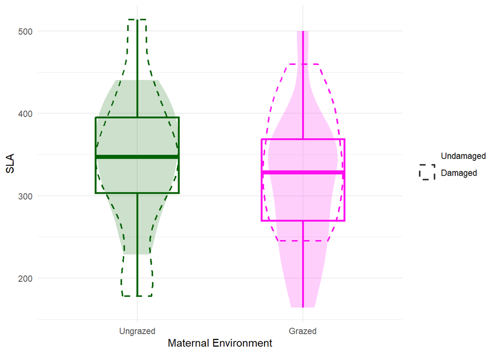

### H.murinum - LDMC

**LDMC ~ trat + clip + trat:clip**  
n = **48**

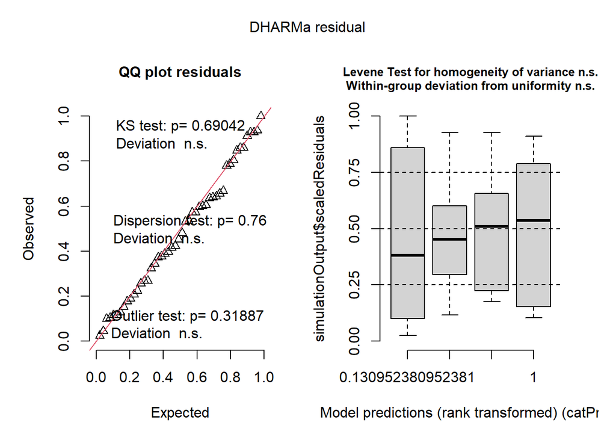

R² = **0.1236166**

##### HOLDMC Post-hoc Comparisons with Tukeys HSD

| contrast | trat | estimate | SE | df | t.ratio | p.value |
| --- | --- | --- | --- | --- | --- | --- |
| no - yes | ex | 0.0125127 | 0.0173864 | 44 | 0.7196857 | 0.4755241 |
| no - yes | gra | 0.0225222 | 0.0153264 | 44 | 1.4695024 | 0.1488110 |

| contrast | clip | estimate | SE | df | t.ratio | p.value |
| --- | --- | --- | --- | --- | --- | --- |
| ex - gra | no | -0.0362467 | 0.0163017 | 44 | -2.22349 | 0.0313647 |
| ex - gra | yes | -0.0262371 | 0.0164754 | 44 | -1.59250 | 0.1184320 |

ANOVA Results for HOLDMC Model

| Response | Predictor | Sum Sq | Df | F value | Pr(>F) |
| --- | --- | --- | --- | --- | --- |
| HO LDMC | trat ** | 0.012 | 1 | 7.293 | 0.010 |
| HO LDMC | clip | 0.004 | 1 | 2.491 | 0.122 |
| HO LDMC | trat:clip | 0.000 | 1 | 0.187 | 0.668 |
| HO LDMC | Residuals | 0.070 | 44 | NA | NA |

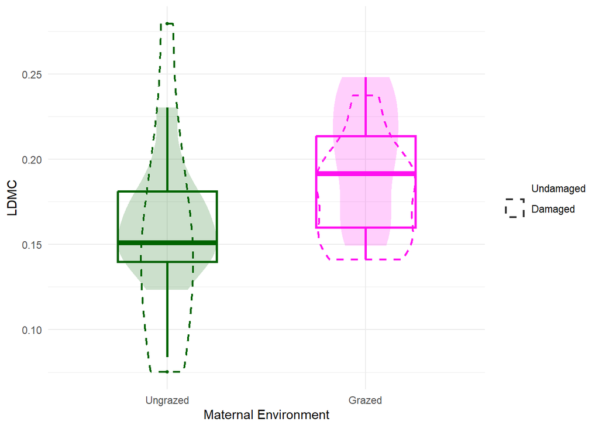

### H.murinum - ÁREA FOLIAR

**area.m ~ trat + clip + trat:clip**  
n = **51**

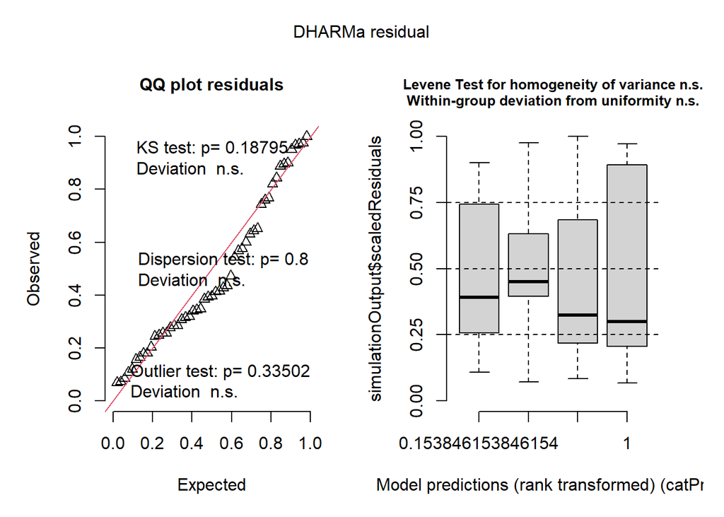

R² = **0.026394**

##### HOarea.m Post-hoc Comparisons with Tukeys HSD

| contrast | trat | estimate | SE | df | t.ratio | p.value |
| --- | --- | --- | --- | --- | --- | --- |
| no - yes | ex | 1.1637500 | 1.128725 | 47 | 1.0310303 | 0.3078032 |
| no - yes | gra | -0.1922308 | 1.064903 | 47 | -0.1805148 | 0.8575246 |

| contrast | clip | estimate | SE | df | t.ratio | p.value |
| --- | --- | --- | --- | --- | --- | --- |
| ex - gra | no | 2.081981 | 1.106806 | 47 | 1.8810707 | 0.0661652 |
| ex - gra | yes | 0.726000 | 1.087667 | 47 | 0.6674837 | 0.5077275 |

ANOVA Results for HOarea.m Model

| Response | Predictor | Sum Sq | Df | F value | Pr(>F) |
| --- | --- | --- | --- | --- | --- |
| HO area.m | trat · | 24.617 | 1 | 3.220 | 0.079 |
| HO area.m | clip | 2.538 | 1 | 0.332 | 0.567 |
| HO area.m | trat:clip | 5.837 | 1 | 0.764 | 0.387 |
| HO area.m | Residuals | 359.274 | 47 | NA | NA |

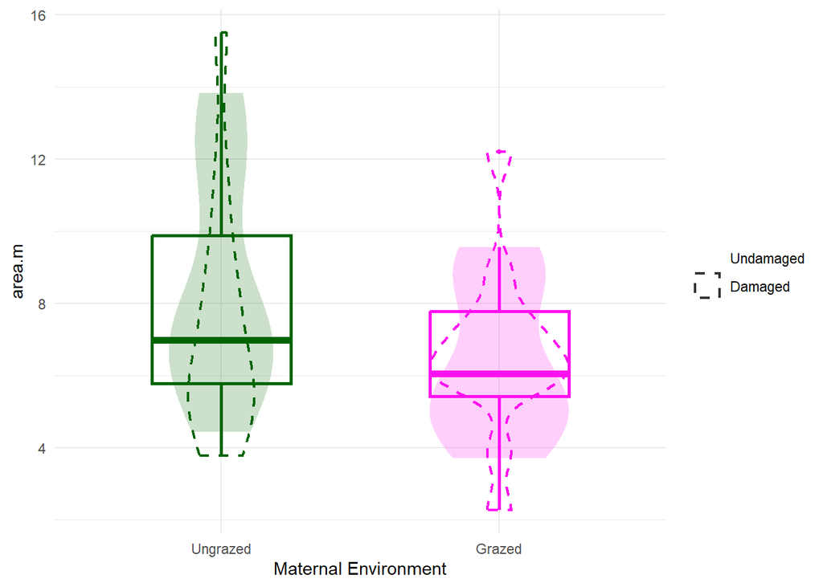

### H.murinum - TASA FOTOSINTÉTICA

**Photosyn ~ trat + clip + trat:clip**  
n = **29**

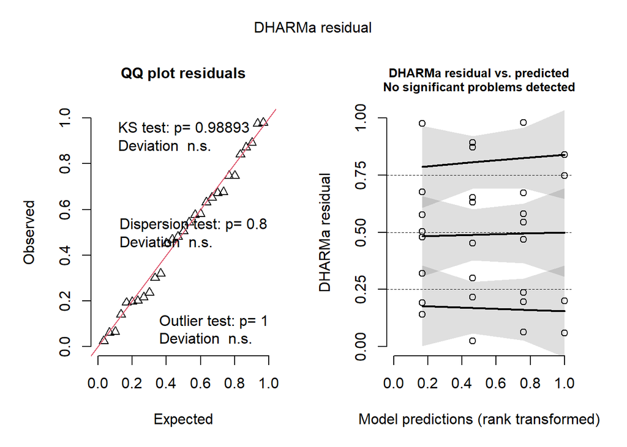

R² = **-0.0130402**

##### HOPhotosyn Post-hoc Comparisons with Tukeys HSD

| contrast | trat | estimate | SE | df | t.ratio | p.value |
| --- | --- | --- | --- | --- | --- | --- |
| no - yes | ex | -0.80 | 2.602317 | 25 | -0.3074183 | 0.7610714 |
| no - yes | gra | -4.18 | 2.967098 | 25 | -1.4087839 | 0.1712159 |

| contrast | clip | estimate | SE | df | t.ratio | p.value |
| --- | --- | --- | --- | --- | --- | --- |
| ex - gra | no | 2.6625 | 2.602317 | 25 | 1.0231266 | 0.3160469 |
| ex - gra | yes | -0.7175 | 2.967098 | 25 | -0.2418188 | 0.8108932 |

ANOVA Results for HOPhotosyn Model

| Response | Predictor | Sum Sq | Df | F value | Pr(>F) |
| --- | --- | --- | --- | --- | --- |
| HO Photosyn | trat | 10.071 | 1 | 0.372 | 0.548 |
| HO Photosyn | clip | 36.453 | 1 | 1.346 | 0.257 |
| HO Photosyn | trat:clip | 19.869 | 1 | 0.733 | 0.400 |
| HO Photosyn | Residuals | 677.205 | 25 | NA | NA |

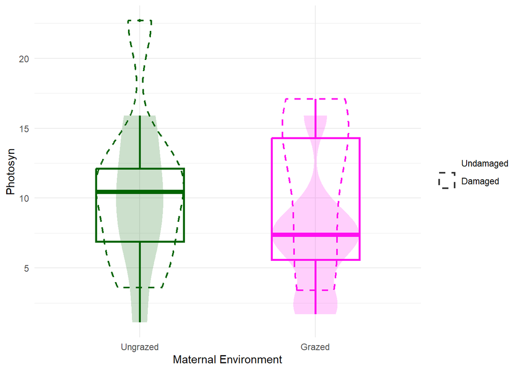

### H.murinum - CONDUCTANCIA ESTOMÁTICA

**Conductance ~ trat + clip + trat:clip**  
n = **29**

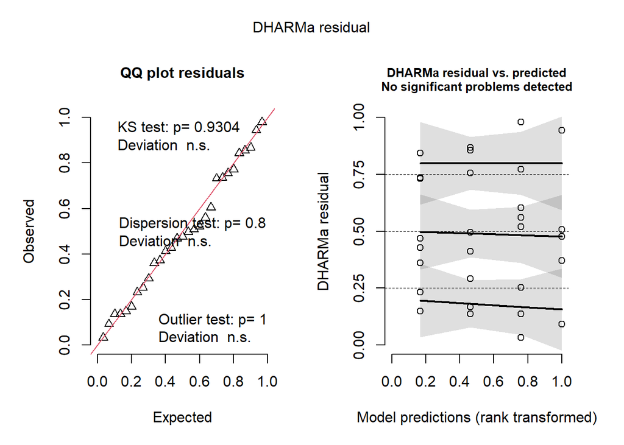

R² = **0.0090376**

##### HOConductance Post-hoc Comparisons with Tukeys HSD

| contrast | trat | estimate | SE | df | t.ratio | p.value |
| --- | --- | --- | --- | --- | --- | --- |
| no - yes | ex | -0.0085 | 0.0297244 | 25 | -0.2859603 | 0.7772647 |
| no - yes | gra | -0.0505 | 0.0338910 | 25 | -1.4900697 | 0.1487154 |

| contrast | clip | estimate | SE | df | t.ratio | p.value |
| --- | --- | --- | --- | --- | --- | --- |
| ex - gra | no | -0.0065 | 0.0297244 | 25 | -0.2186756 | 0.8286781 |
| ex - gra | yes | -0.0485 | 0.0338910 | 25 | -1.4310571 | 0.1647964 |

ANOVA Results for HOConductance Model

| Response | Predictor | Sum Sq | Df | F value | Pr(>F) |
| --- | --- | --- | --- | --- | --- |
| HO Conductance | trat | 0.004 | 1 | 1.228 | 0.278 |
| HO Conductance | clip | 0.005 | 1 | 1.434 | 0.242 |
| HO Conductance | trat:clip | 0.003 | 1 | 0.868 | 0.360 |
| HO Conductance | Residuals | 0.088 | 25 | NA | NA |

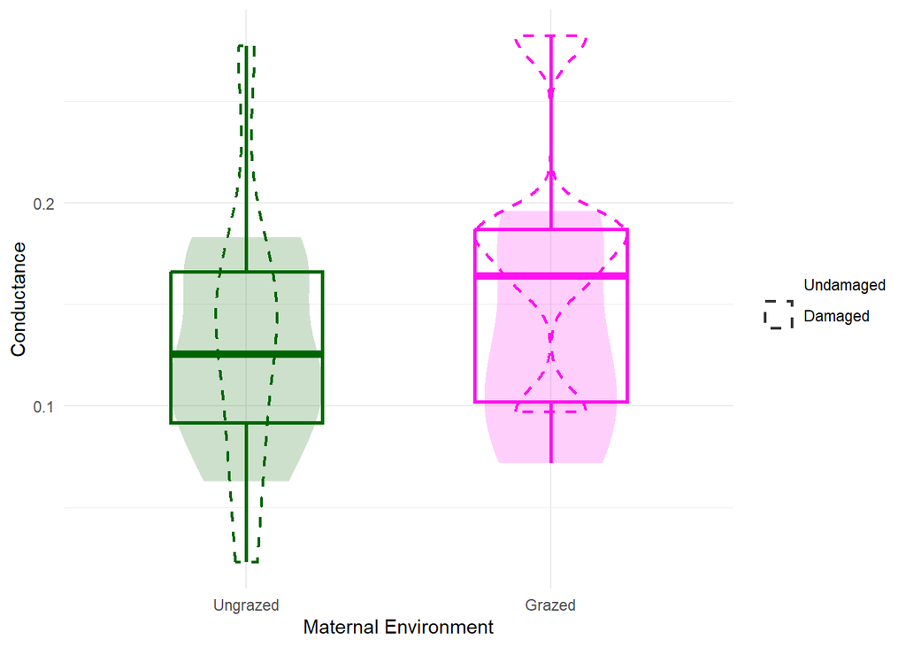

### H.murinum - EFICIENCIA DEL FOTOSISTEMA II

**PhiPS2 ~ trat + clip + trat:clip**  
n = **29**

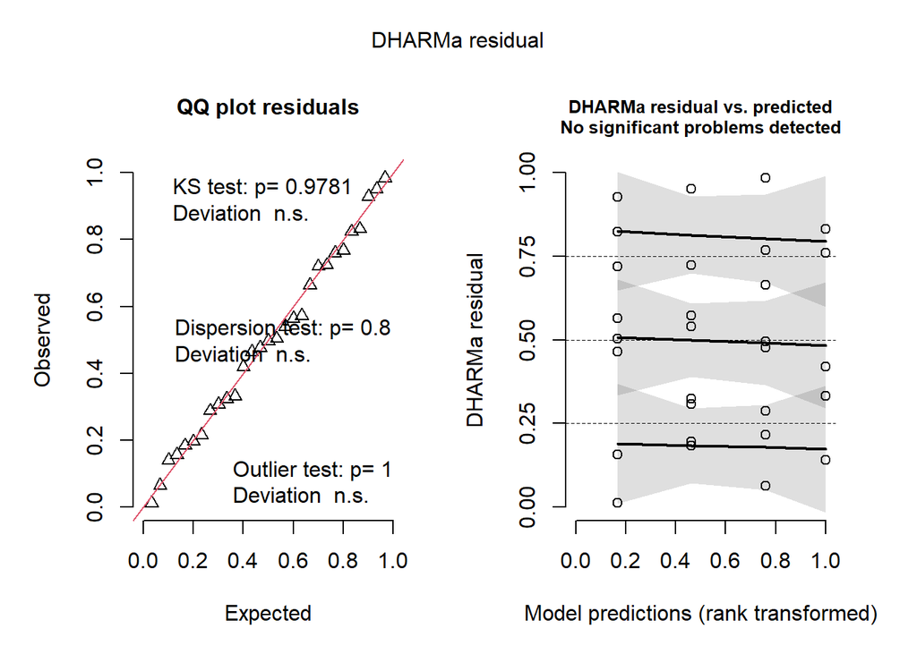

R² = **0.1686961**

##### HOPhiPS2 Post-hoc Comparisons with Tukeys HSD

| contrast | trat | estimate | SE | df | t.ratio | p.value |
| --- | --- | --- | --- | --- | --- | --- |
| no - yes | ex | 0.015625 | 0.0230262 | 25 | 0.6785757 | 0.5036404 |
| no - yes | gra | -0.055525 | 0.0262539 | 25 | -2.1149260 | 0.0445772 |

| contrast | clip | estimate | SE | df | t.ratio | p.value |
| --- | --- | --- | --- | --- | --- | --- |
| ex - gra | no | -0.004125 | 0.0230262 | 25 | -0.179144 | 0.8592686 |
| ex - gra | yes | -0.075275 | 0.0262539 | 25 | -2.867196 | 0.0082879 |

ANOVA Results for HOPhiPS2 Model

| Response | Predictor | Sum Sq | Df | F value | Pr(>F) |
| --- | --- | --- | --- | --- | --- |
| HO PhiPS2 | trat · | 0.009 | 1 | 4.102 | 0.054 |
| HO PhiPS2 | clip | 0.002 | 1 | 0.782 | 0.385 |
| HO PhiPS2 | trat:clip · | 0.009 | 1 | 4.151 | 0.052 |
| HO PhiPS2 | Residuals | 0.053 | 25 | NA | NA |

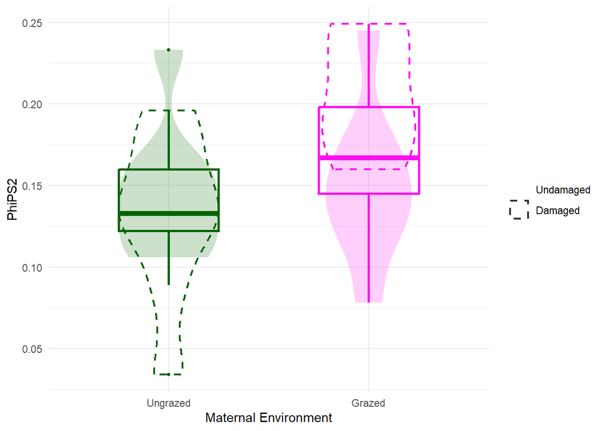

### H.murinum - FENOLOGÍA DE FLORACIÓN

**dias_flor ~ trat + clip + trat:clip**  
n = **24**

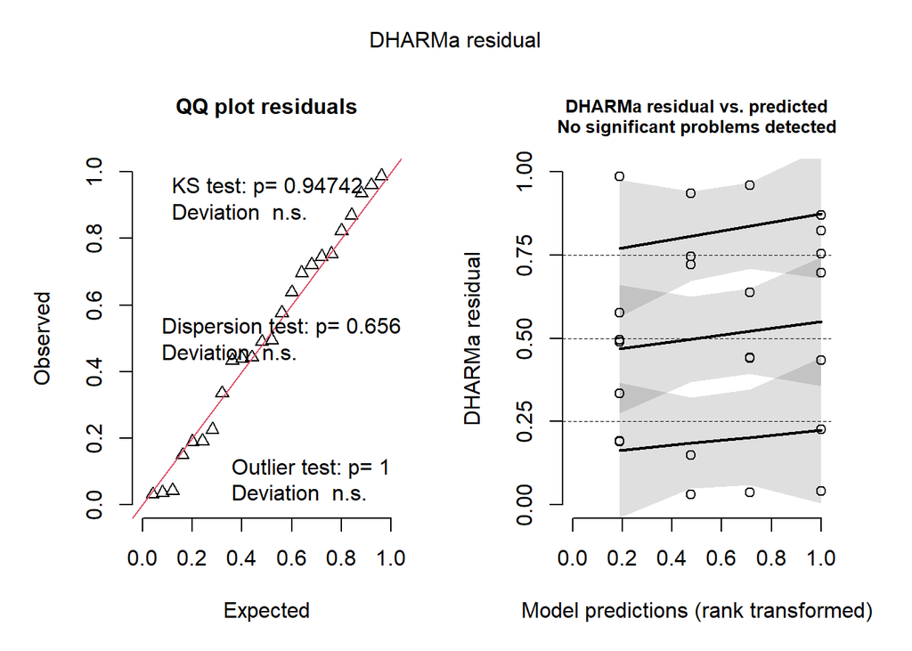

##### HOdias_flor Post-hoc Comparisons with Tukeys HSD

| contrast | trat | estimate | SE | df | z.ratio | p.value |
| --- | --- | --- | --- | --- | --- | --- |
| no - yes | ex | 0.0397607 | 0.0857771 | Inf | 0.4635355 | 0.6429806 |
| no - yes | gra | 0.1978577 | 0.0729423 | Inf | 2.7125254 | 0.0066773 |

| contrast | clip | estimate | SE | df | z.ratio | p.value |
| --- | --- | --- | --- | --- | --- | --- |
| ex - gra | no | -0.054394 | 0.0787260 | Inf | -0.6909285 | 0.4896105 |
| ex - gra | yes | 0.103703 | 0.0805015 | Inf | 1.2882115 | 0.1976724 |

ANOVA Results for HOdias_flor Model

| Response | Predictor | Chisq | Df | Pr(>Chisq) |
| --- | --- | --- | --- | --- |
| HO dias_flor | trat | 0.165 | 1 | 0.684 |
| HO dias_flor | clip * | 5.601 | 1 | 0.018 |
| HO dias_flor | trat:clip | 1.971 | 1 | 0.160 |

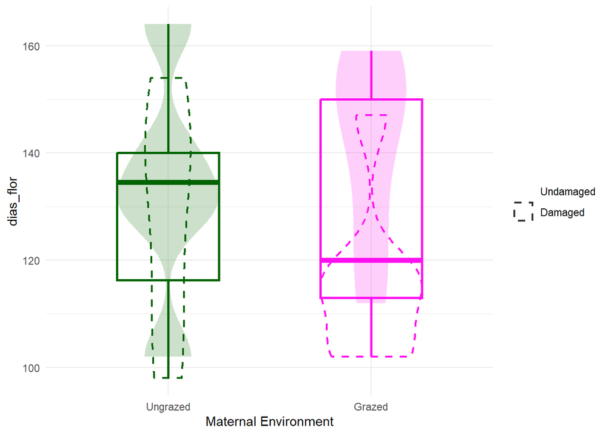

### H.murinum - FENOLOGÍA DE FRUCTIFICACÓN

**dias_fruto ~ trat + clip + trat:clip**  
n = **15**

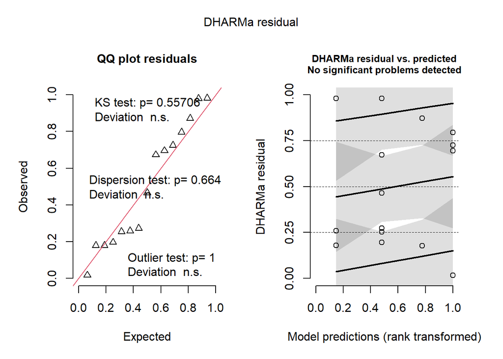

##### HOdias_fruto Post-hoc Comparisons with Tukeys HSD

| contrast | trat | estimate | SE | df | z.ratio | p.value |
| --- | --- | --- | --- | --- | --- | --- |
| no - yes | ex | 0.0548583 | 0.1120000 | Inf | 0.4898059 | 0.6242713 |
| no - yes | gra | 0.1553999 | 0.0780682 | Inf | 1.9905658 | 0.0465286 |

| contrast | clip | estimate | SE | df | z.ratio | p.value |
| --- | --- | --- | --- | --- | --- | --- |
| ex - gra | no | -0.1030449 | 0.1048569 | Inf | -0.9827188 | 0.3257458 |
| ex - gra | yes | -0.0025032 | 0.0874281 | Inf | -0.0286317 | 0.9771584 |

ANOVA Results for HOdias_fruto Model

| Response | Predictor | Chisq | Df | Pr(>Chisq) |
| --- | --- | --- | --- | --- |
| HO dias_fruto | trat | 0.424 | 1 | 0.515 |
| HO dias_fruto | clip · | 3.660 | 1 | 0.056 |
| HO dias_fruto | trat:clip | 0.542 | 1 | 0.461 |

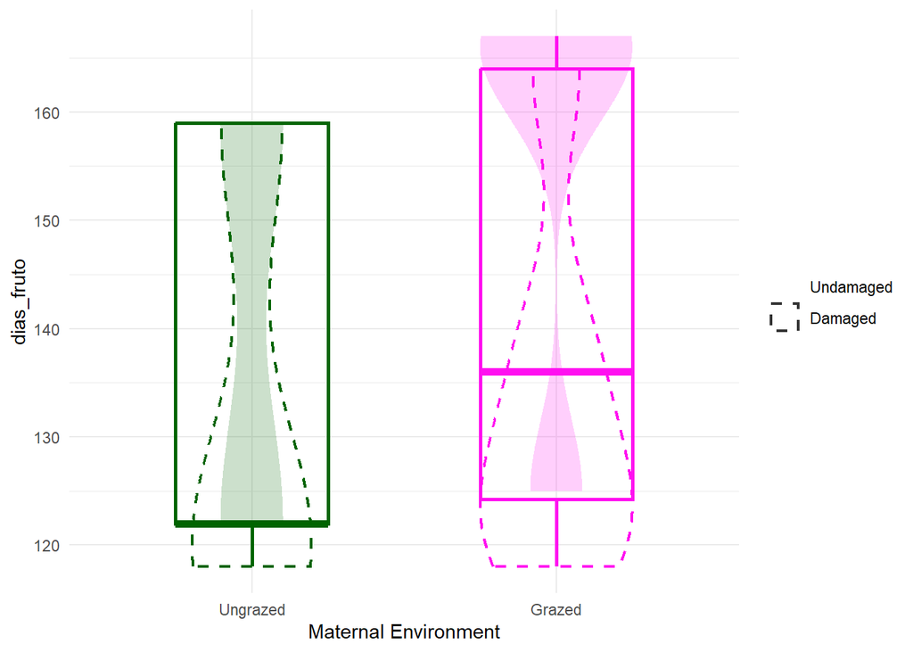